# Analysis - Daims Nitrospira 3 GWW assembly

Mads Albertsen

November 24, 2015

## Introduction

This report documents the binning of a Nitrospira genome from the GWW sample. See [Daims et al., 2015: Complete Nitrification by Nitrospira Bacteria](https://doi.org/10.1038/nature16461) for further details.

## Load the mmgenome package

The metagenome data is analysed using the [mmgenome package](http://madsalbertsen.github.io/mmgenome/).

```r
library("mmgenome")
```

## Import data

The Rmarkdown file [Load_data.Rmd](http://madsalbertsen.github.io/mmgenome/Daims_GWW_Load_data.html) describes the loading of the data and can be imported using the `mmimport` function. However, the preprocessed data can also be downloaded directly from figshare: [Daims_GWW](http://dx.doi.org/10.6084/m9.figshare.1613284). Hence, here we import the prepocessed data from figshare instead.

```r
load("Daims_GWW.RData")
```

## Extract Nitrospira 3

This Nitrospira seem to assemble very nicely. Hence, additional effort is done to obtain a clean genome bin.

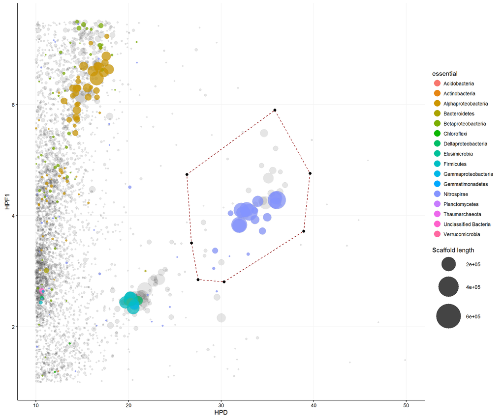

```r
p <- mmplot(data = d,
            x = "HPD",
            y = "HPF1",
            log.x = F,
            log.y = F,
            color = "essential",
            minlength = 1000,
            factor.shape = "solid") +
  xlim(10, 50) +
  ylim(1, 7.5)

#p
#sel <- mmplot_locator(p)

sel <- data.frame(HPD  =  c(26.8, 27.5, 30.3, 38.9, 39.6, 35.8, 26.3),
                  HPF1  =  c(3.51, 2.85, 2.81, 3.72, 4.76, 5.9, 4.74))

mmplot_selection(p, sel)
```

The scaffolds included in the defined subspace are extracted using the `mmextract` function. One scaffold is excluded using network plots.

```r
dA <- mmextract(d, sel, exclude = "47021")
```

The `mmstats` function applies to any extracted object. Hence, it can be used directly on the subset.

```r
mmstats(dA, ncov = 2)
```

```
##               General Stats
## n.scaffolds           49.00
## GC.mean               55.80
## N50               155638.00
## Length.total     3443025.00
## Length.max        320146.00
## Length.mean        70265.80
## Coverage.HPD          33.75
## Coverage.HPF1          4.15
## Ess.total             91.00
## Ess.unique            90.00
```

## Subset B

Unsing PE reads.

```r
dB <- mmextract_network(subset = dA,
                        original = d,
                        network = pe,
                        nconnections = 1,
                        type = "direct")
```

… and then plot the new subset.

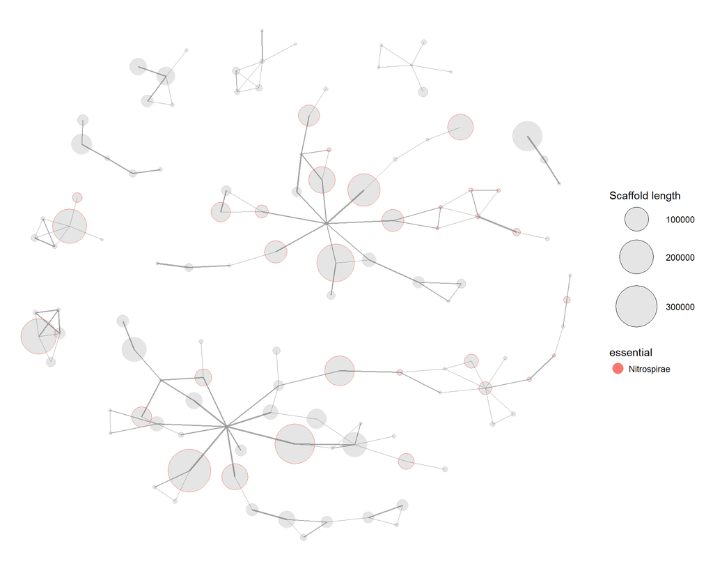

```r
mmplot_network(data = dB,
               network = pe,
               nconnections = 1,
               color = "essential",
               scale.links = 0.5)
```

## Subset C

We do a final selection to remove other Nitrospira scaffolds that were included.

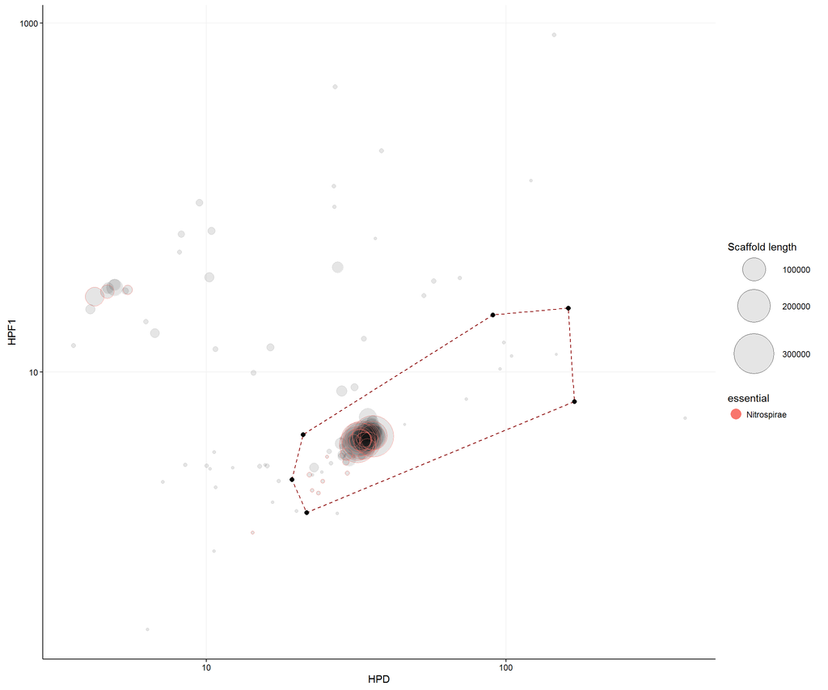

```r
p <- mmplot(data = dB,
            x = "HPD",
            y = "HPF1",
            log.x = T,
            log.y = T,
            color = "essential",
            minlength = 1000)
#p
#sel <- mmplot_locator(p)

sel <- data.frame(HPD  =  c(19.3, 21, 90.2, 161, 169, 21.6),
                  HPF1  =  c(2.42, 4.38, 21.2, 23.2, 6.76, 1.56))

mmplot_selection(p, sel)
```

The scaffolds included in the defined subspace are extracted using the `mmextract` function.

```r
dC <- mmextract(dB, sel)
```

The `mmstats` function applies to any extracted object. Hence, it can be used directly on the subset.

```r
mmstats(dC, ncov = 2)
```

```
##               General Stats
## n.scaffolds           66.00
## GC.mean               55.80
## N50               155638.00
## Length.total     3487713.00
## Length.max        320146.00
## Length.mean        52844.10
## Coverage.HPD          33.77
## Coverage.HPF1          4.15
## Ess.total            106.00
## Ess.unique            99.00
```

## Export the scaffolds

Finally the binned scaffolds are exported.

```r
mmexport(data = dC, assembly = assembly, file = "GWW_Nitrospira3.fa")
```